# Third Week: Exploratory Data Analysis

LaLiga Analysis

Mohammad amin Roohi

2018-02-27 02:23:16

# تمرین سری سوم: از لالیگا تا لیگ برتر

> با استفاده از داده های لیگ دسته اول اسپانیا به سوالات زیر پاسخ دهید. از هر دو ابزار ggplot2 و highcharter برای این کار تصویرسازی استفاده نمایید.

۱. تعداد قهرمانی های تیم ها در تاریخ لالیگا را استخراج کرده و نمودار ستونی آنها را رسم کنید.

```r
library(devtools)
install_github('jalapic/engsoccerdata', username = "jalapic")
```

```
## from URL https://api.github.com/repos/jalapic/engsoccerdata/zipball/master
```

```
## Installing engsoccerdata
```

[output not shown]

```r
library(engsoccerdata)
data(package="engsoccerdata")    # lists datasets currently available
library(dplyr)
```

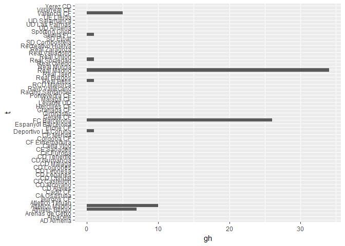

```r
library(highcharter)
library(ggplot2)
fdb = as.tbl(spain)

y = unique(fdb$Season)

t = unique(fdb$home)

gh = rep(0 , length(t))

for(k in y){


  fdb %>% filter(Season == k) -> a

  a %>% mutate(hscore = sign(hgoal - vgoal) + 1 , vscore = sign(vgoal -hgoal) + 1) -> a

  d = dim(a)

  d = d[1]


  for(i in 1:d){

    if(a[i , 13] == 2){

      a[i , 13] = 3
    }

    if(a[i , 14] == 2){

      a[i , 14] = 3
    }
  }

  t1 = unique(a$home)


  t1 = sort(t1)

  s = NULL

  for(i in t1){

    a %>% filter(home == i) %>% summarise(h = sum(hscore)) -> a1

    a %>% filter(visitor == i) %>% summarise(v = sum(vscore)) -> a2



    a1 = as.integer(a1)

    a2 = as.integer(a2)


    s = c(s , a1 + a2)



  }


  f = match(max(s) , s)

  f = t1[f]

  f = match(f , t)

  gh[f] = gh[f] + 1



}
da = data.frame(t , gh)

ggplot(da , aes(t , gh)) + geom_col() + coord_flip()
```

۲. کسل کننده ترین لیگ و تیم را بیابید. نمودار ده تیم و ده فصل کسل کننده را رسم کنید.

```r
fdb %>% mutate(jazabiat = hgoal + vgoal) -> a

t = unique(fdb$home)

y = unique(fdb$Season)

y = sort(y)

jaz_s = NULL

jaz_t = NULL

for(i in y){

  a %>% filter(Season == i) %>% summarise(js = sum(jazabiat)) -> b

  b = as.integer(b)

  c = dim(a %>% filter(Season == i))

  c = c[1]

  b = b/c

  jaz_s = c(jaz_s ,b)

}

for(i in t){

  a %>% filter(home == i) %>% summarise(js = sum(jazabiat)) -> b

  a %>% filter(visitor == i) %>% summarise(js = sum(jazabiat)) -> c

  k = dim(a %>% filter(home == i)) + dim(a %>% filter(visitor == i))

  k = k[1]

  b = as.integer(b) + as.integer(c)

  b = b/k

  jaz_t = c(jaz_t ,b)

}


kl = match(min(jaz_t) , jaz_t)

kl = t[kl]


ks = match(min(jaz_s) , jaz_s)

ks = y[ks]

kl
```

```
## [1] "Real Burgos"
```

```r
ks
```

```
## [1] 1972
```

۳. در چند درصد موارد قهرمان نیم فصل در پایان فصل قهرمان شده است؟

```r
y = unique(fdb$Season)

n_gh_h = 0

for(i in y){

  fdb %>% filter(Season == i) -> s

  d = dim(s)

  d = d[1]

  s %>% mutate(hscore = sign(hgoal - vgoal) + 1 , vscore = sign(vgoal -hgoal) + 1) -> s

  for(i in 1:d){

    if(as.integer(s[i , 13]) == 2){

      s[i , 13] = 3
    }

    if(as.integer(s[i , 14]) == 2){

      s[i , 14] = 3
    }
  }


  s_h = s[1:(d/2) , ]

  t1 = unique(s$home)


  t1 = sort(t1)

  k = NULL

  for(i in t1){

    s_h %>% filter(home == i) %>% summarise(h = sum(hscore)) -> s1

    s_h %>% filter(visitor == i) %>% summarise(v = sum(vscore)) -> s2



    s1 = as.integer(s1)

    s2 = as.integer(s2)


    k = c(k , s1 + s2)

  }

    f_h = match(max(k) , k)



  k = NULL

  for(i in t1){

    s %>% filter(home == i) %>% summarise(h = sum(hscore)) -> s1

    s %>% filter(visitor == i) %>% summarise(v = sum(vscore)) -> s2



    s1 = as.integer(s1)

    s2 = as.integer(s2)


    k = c(k , s1 + s2)

  }


    f = match(max(k) , k)


    if(f == f_h){

      n_gh_h = n_gh_h + 1

    }



}

ratio = n_gh_h / length(unique(fdb$Season))

print(ratio)
```

```
## [1] 0.5348837
```

۴. در بین سال های ۲۰۰۱ تا ۲۰۱۰ گربه سیاه تیم های بزرگ چه تیم هایی بوده است؟

```r
for(r in 2001:2010){

  fdb %>% filter(Season == r) -> s

  t1 = unique(fdb$home)

  t1 = sort(t1)

  d = dim(s)

  d = d[1]

  s %>% mutate(hscore = sign(hgoal - vgoal) + 1 , vscore = sign(vgoal -hgoal) + 1) -> s

  for(i in 1:d){

    if(s[i , 13] == 2){

      s[i , 13] = 3
    }

    if(s[i , 14] == 2){

      s[i , 14] = 3
    }
  }

  k = NULL

  for(i in t1){

    s %>% filter(home == i) %>% summarise(h = sum(hscore)) -> s1

    s %>% filter(visitor == i) %>% summarise(v = sum(vscore)) -> s2



    s1 = as.integer(s1)

    s2 = as.integer(s2)


    k = c(k , s1 + s2)

  }


  k1 = sort(k)

  b = tail(k1 , 4)

  b = match(b , k)

  b = t1[b]


  s_t = rep(0 , length(t1))

  for(j in b){

    s %>% filter(home == j) %>% filter(hgoal < vgoal) -> s1

    s1 = s1$visitor

    el = NULL

    for(i in 1:length(s1)){

      if(sum(s1[i] == b , na.rm = T) == 1){

        el = c(el , i)
      }
    }

    if(length(el) > 0){

      s1 = s1[-el]
    }



    s1 = match(s1 , t1)

    s_t[s1] = s_t[s1] + 1

    s %>% filter(visitor == j) %>% filter(vgoal < hgoal) -> s1

    s1 = s1$home

    el = NULL

    for(i in 1:length(s1)){

      if(sum(s1[i] == b , na.rm = T) == 1){

        el = c(el , i)
      }
    }

    if(length(el) > 0){

      s1 = s1[-el]
    }


    s1 = match(s1 , t1)

    s_t[s1] = s_t[s1] + 1


  }

  v = NULL

  for(i in 1:61){

    if(max(s_t) == s_t[i]){

      v = c(v , i)


    }


  }

  v1 = t1[v]

  print(c("Gorbesiah in " , r , ">>>>", v1))









}
```

```
## [1] "Gorbesiah in "      "2001"               ">>>>"
## [4] "Athletic Bilbao"    "Espanyol Barcelona" "Rayo Vallecano"
## [7] "Real Valladolid"
## [1] "Gorbesiah in "    "2002"             ">>>>"
## [4] "Athletic Bilbao"  "Racing Santander" "Real Betis"
## [1] "Gorbesiah in " "2003"          ">>>>"          "CA Osasuna"
## [5] "RCD Mallorca"  "Villarreal CF"
## [1] "Gorbesiah in "       "2004"                ">>>>"
## [4] "Athletic Bilbao"     "Deportivo La Coruna" "Sevilla FC"
## [1] "Gorbesiah in " "2005"          ">>>>"          "Sevilla FC"
## [1] "Gorbesiah in " "2006"          ">>>>"          "Real Madrid"
## [1] "Gorbesiah in " "2007"          ">>>>"          "Real Betis"
## [1] "Gorbesiah in "   "2008"            ">>>>"            "Real Valladolid"
## [1] "Gorbesiah in "   "2009"            ">>>>"            "Atletico Madrid"
## [5] "Getafe CF"
## [1] "Gorbesiah in " "2010"          ">>>>"          "CA Osasuna"
## [5] "Sevilla FC"
```

۵. در تاریخ لالیگا کدام تیم رکورددار زودترین قهرمانی است؟ همچنین کدام تیم مقتدرانه ترین قهرمانی را داشته است؟

```r
y = unique(fdb$Season)

x = NULL

z = NULL

fdb %>% mutate(hscore = sign(hgoal - vgoal) + 1 , vscore = sign(vgoal -hgoal) + 1) -> fdb

d1 = dim(fdb)

d1 = d1[1]


for(k in 1:d1){

  if(as.integer(fdb[k , 13]) == 2){

    fdb[k , 13] = 3
  }

  if(as.integer(fdb[k , 14]) == 2){

    fdb[k , 14] = 3
  }
}

for(i in y){




  fdb %>% filter(Season == i) -> a

  t = length(unique(a$home))

  d = dim(a)

  d = d[1]

  w = d / (t/2)

  q = rep(0 , w)


  for(j in (w-10):w){

    b = a[1 : (j * (t/2)) , ]

    d1 = dim(b)

    d1 = d1[1]




    t1 = unique(a$home)


    t1 = sort(t1)

    s = NULL

    for(p in t1){

      b %>% filter(home == p) %>% summarise(h = sum(hscore)) -> a1

      b %>% filter(visitor == p) %>% summarise(v = sum(vscore)) -> a2



      a1 = as.integer(a1)

      a2 = as.integer(a2)


      s = c(s , a1 + a2)



    }


    s1 = sort(s , decreasing = T)

    k = s1[1] - s1[2]

    if(k > 3*(w - j)){

      q[j] = q[j] + 1

      break
    }



  }


  r = match(1 , q)


  x = c(x , w - r)

  v = match(s1[1] , s)

  v = t1[v]

  f = c(v , "with" , w - r , "weeks sooner in season" , i)

  f = paste(f , collapse = " ")

  z = c(z , f)



}

h = NULL

x[is.na(x)] <- 0

for(i in 1:length(x)){

  if(x[i] == max(x , na.rm = T)){

    print(z[i])

  }
}
```

```
## [1] "Real Madrid with 5 weeks sooner in season 1960"
## [1] "Real Madrid with 5 weeks sooner in season 1962"
## [1] "FC Barcelona with 5 weeks sooner in season 1973"
## [1] "Real Madrid with 5 weeks sooner in season 1974"
## [1] "FC Barcelona with 5 weeks sooner in season 1990"
```

```r
#powerful champion


y = fdb$Season

y = unique(y)

hgh = NULL

gh = NULL

for(k in y){


  fdb %>% filter(Season == k) -> a

  a %>% mutate(hscore = sign(hgoal - vgoal) + 1 , vscore = sign(vgoal -hgoal) + 1) -> a

  d = dim(a)

  d = d[1]


  for(i in 1:d){

    if(a[i , 13] == 2){

      a[i , 13] = 3
    }

    if(a[i , 14] == 2){

      a[i , 14] = 3
    }
  }

  t1 = unique(a$home)


  t1 = sort(t1)

  s = NULL

  for(i in t1){

    a %>% filter(home == i) %>% summarise(h = sum(hscore)) -> a1

    a %>% filter(visitor == i) %>% summarise(v = sum(vscore)) -> a2



    a1 = as.integer(a1)

    a2 = as.integer(a2)


    s = c(s , a1 + a2)



  }


  s1 = sort(s , decreasing = T)

  hgh = c(hgh , (s1[1] - s1[2]))

  q = match(max(s) , s)

  gh = c(gh , t1[q])





}

k = match(max(hgh) , hgh)

w = c("powerful champion is" , gh[k], "in Season" , 1928 + k - 1)

print(w)
```

```
## [1] "powerful champion is" "Real Madrid"          "in Season"
## [4] "1959"
```

۶. طولانی ترین نوار پیروزی مساوی و شکست مال چه تیم هایی است؟

```r
y = unique(fdb$home)

y = sort(y)

w = NULL

e = NULL

l = NULL


for(i in y){

  x = NULL


  fdb %>% filter(home == i  |  visitor == i) -> a



  d = dim(a)

  d = d[1]


  for(j in 1:d){

    if(as.character(a[j , 3]) == i && (as.integer(a[j , 7]) > as.integer(a[j , 8]))){

      x = c(x , "w")


    }


    if(as.character(a[j , 4]) == i && (as.integer(a[j , 8]) > as.integer(a[j , 7]))){

      x = c(x , "w")


    }


    if(as.character(a[j , 3]) == i && (as.integer(a[j , 8])> as.integer(a[j , 7]))){

      x = c(x , "l")


    }


    if(as.character(a[j , 4]) == i && (as.integer(a[j , 7])  > as.integer(a[j , 8]))){

      x = c(x , "l")


    }

    if(as.character(a[j , 3]) == i && (as.integer(a[j , 8]) == as.integer(a[j , 7]))){

      x = c(x , "e")


    }


    if(as.character(a[j , 4]) == i && (as.integer(a[j , 7])  == as.integer(a[j , 8]))){

      x = c(x , "e")


    }




  }

  x = paste(x , collapse = "")

  x = rle(strsplit(x,"")[[1]])

  x_w = max(x$lengths[which(x$values == "w")])

  x_e = max(x$lengths[which(x$values == "e")])

  x_l = max(x$lengths[which(x$values == "l")])



  w = c(w , x_w)

  e = c(e , x_e)

  l = c(l , x_l)





}



wf = match(max(w) , w)

wff = NULL
for(i in 1:61){

  if(w[i] == max(w)){

    wff = c(wff , i)

  }
}


k1 = c("maximum consecutive win >>>" , y[wff] , "with" , max(w) , "wins")

print(k1)
```

```
## [1] "maximum consecutive win >>>" "FC Barcelona"
## [3] "Real Madrid"                 "with"
## [5] "16"                          "wins"
```